# DDS Case Study 1

Armando Vela & Paul Adams

June 25, 2019

## P&A Consulting Group

#### https://github.com/avela0317/SMU-Case-Study-1

#### Budweiser Inc. Beer & Brewery Analysis

After carefully reviewing the beer offerings data and brewery data provided by your company, our consulting group was able to uncover helpful information in choosing which beer type to offer within specific US states. Our analysis, listed below, mainly dealt with reviewing the alcohol content (ABV) and international bitterness unit (IBU) for each beer type within each state.

Some findings we identified were that if your company hoped to offer a more bitter beer (higher IBU), than the state of Maine should be used for the initial roll-out since the citizens are already accustomed to a more bitter beer since it has the highest median IBU value in the US. Also, if you were going to be offering a lighter beer, than the state of Utah would probably best since there median ABV is the lowest in the US.

Within the writeup below you can find our analysis, regarding the beer & brewery data provided.

```r
library(tidyverse)
```

```r
library(ggplot2)
library(reshape2)
library(dplyr)
library(na.tools)
library(sqldf)
#Set working directory
setwd("C:/Users/Pablo/Desktop/DS 6306 - Doing Data Science/Unit 7")

# Read CSV into R
beerData <- read.csv(file="Beers.csv", header=TRUE, sep=",")

breweryData <- read.csv(file="Breweries.csv", header=TRUE, sep=",")
```

#### 1. How many breweries are present in each state?

The image below displays the number of breweries present in each state. As you will see, Colorado has highest the amount of breweries with 47. Also, the following states are tied for having the the lowest amount of breweries with 1: West Virginia, South Dakota, North Dakota, & the District of Columbia.

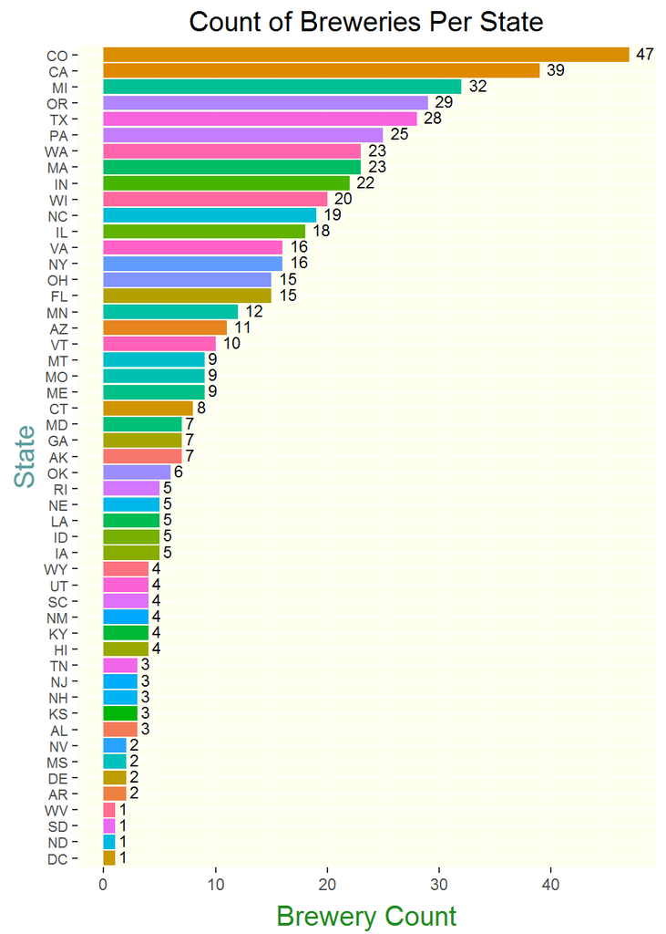

```r
#count of breweries per state
StateBrewCnt <- sqldf("select State, count(*) as Brewery_Count
                      from breweryData
                      group by State
                      order by Brewery_Count desc")

ggplot(data=StateBrewCnt, aes(x=reorder(State,Brewery_Count),y=Brewery_Count,fill=State)) +
  geom_bar(stat="identity", show.legend = F) +
  ggtitle("Count of Breweries Per State") +
  coord_flip() +
  geom_text(data = StateBrewCnt,
            aes(y = Brewery_Count, label = substr(Brewery_Count,0,5)), size = 3,
            vjust = .35, hjust=-.4) +
  xlab("State") +
  ylab("Brewery Count") +
  theme(
        panel.background = element_rect(fill = 'ivory1'),
        plot.title = element_text(hjust = 0.5, size=15),
        axis.text.y = element_text(size=8),
        axis.title.x = element_text(color="forestgreen", vjust=-0.35, size=15),
        axis.title.y = element_text(color="cadetblue" , vjust=0.35, size=15)
        )
```

#### 2. Merge beer data with the breweries data. Print the first 6 observations and the last six observations to check the merged file.

To further our analysis, we have combined the brewery data set with the beer data set. Within the image below, we have listed the first 6 rows & last 6 rows of the combined data.

```r
#Merging the two datasets based on Brewery ID
beersAndPubs <- merge(beerData,breweryData, by.x = "Brewery_id", by.y = "Brew_ID", all.x = TRUE)

names(beersAndPubs) <- c("Brewery_ID","Beer_Name","Beer_ID","ABV","IBU","Style","Ounces","Brewery_Name","City","State")

#Display first 6 rows and last 6 rows
head(beersAndPubs, 6)
```

```
##   Brewery_ID     Beer_Name Beer_ID   ABV IBU
## 1          1  Get Together    2692 0.045  50
## 2          1 Maggie's Leap    2691 0.049  26
## 3          1    Wall's End    2690 0.048  19
## 4          1       Pumpion    2689 0.060  38
## 5          1    Stronghold    2688 0.060  25
## 6          1   Parapet ESB    2687 0.056  47
##                                 Style Ounces       Brewery_Name
## 1                        American IPA     16 NorthGate Brewing
## 2                  Milk / Sweet Stout     16 NorthGate Brewing
## 3                   English Brown Ale     16 NorthGate Brewing
## 4                         Pumpkin Ale     16 NorthGate Brewing
## 5                     American Porter     16 NorthGate Brewing
## 6 Extra Special / Strong Bitter (ESB)     16 NorthGate Brewing
##          City State
## 1 Minneapolis    MN
## 2 Minneapolis    MN
## 3 Minneapolis    MN
## 4 Minneapolis    MN
## 5 Minneapolis    MN
## 6 Minneapolis    MN
```

```r
tail(beersAndPubs,6)
```

```
##      Brewery_ID                 Beer_Name Beer_ID   ABV IBU
## 2405        556             Pilsner Ukiah      98 0.055  NA
## 2406        557  Heinnieweisse Weissebier      52 0.049  NA
## 2407        557           Snapperhead IPA      51 0.068  NA
## 2408        557         Moo Thunder Stout      50 0.049  NA
## 2409        557         Porkslap Pale Ale      49 0.043  NA
## 2410        558 Urban Wilderness Pale Ale      30 0.049  NA
##                        Style Ounces                  Brewery_Name
## 2405         German Pilsener     12         Ukiah Brewing Company
## 2406              Hefeweizen     12       Butternuts Beer and Ale
## 2407            American IPA     12       Butternuts Beer and Ale
## 2408      Milk / Sweet Stout     12       Butternuts Beer and Ale
## 2409 American Pale Ale (APA)     12       Butternuts Beer and Ale
## 2410        English Pale Ale     12 Sleeping Lady Brewing Company
##               City State
## 2405         Ukiah    CA
## 2406 Garrattsville    NY
## 2407 Garrattsville    NY
## 2408 Garrattsville    NY
## 2409 Garrattsville    NY
## 2410     Anchorage    AK
```

#### 3. Report the number of NA’s in each column.

After continuing to review the combined data set, our group has identified a number of NAs (ie. missing values) within a few columns. These will be reviewed and addressed within the next section.

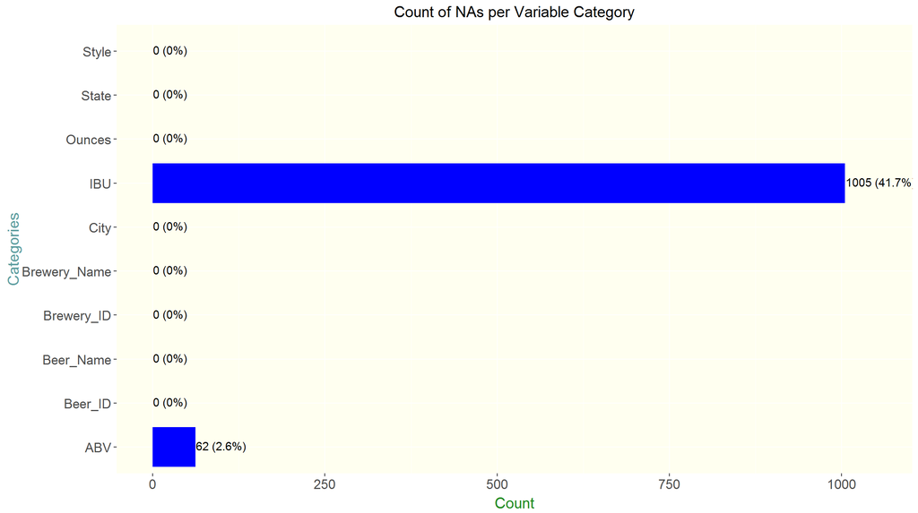

```r
#Gather count of NA
na_count <-sapply(beersAndPubs,
                  function(cnt) sum(length(which(is.na(cnt)))))

# Collect the percent of all NA values representative of the total count of all rows in the data set
percentNA <- ((na_count/(nrow(beersAndPubs)))*100)
percentNA <- paste0(round(percentNA, digits = 1),"%")

# Create a count of NAs with percents in parentheses
percentCountNA <- paste(na_count," (",percentNA,")",sep="")

#Convert count vector to dataframe
na_df <- data.frame(na_count)

#Add new variable to list category names
na_df$categories <- c("Brewery_ID","Beer_Name","Beer_ID","ABV","IBU","Style","Ounces","Brewery_Name","City","State")

#plot the count data
ggplot(data=na_df, aes(x=categories, y=na_count)) +
  geom_bar(stat="identity", fill="blue") +
  ggtitle("Count of NAs per Variable Category") +
  coord_flip() +
  geom_text(
            data = na_df,
            aes(y = na_count,
                label = percentCountNA
                ),
            size = 4,
            vjust = .35, hjust=-.01) +
  ylim(0,1050) +
  theme(
        panel.background = element_rect(fill = 'ivory1'),
        axis.text.y = element_text(size=13),
        axis.text.x = element_text(size=13),
        axis.title.x = element_text(color="forestgreen", vjust=-0.35, size=15),
        axis.title.y = element_text(color="cadetblue" , vjust=0.35, size=15),
        plot.title = element_text(hjust = 0.5, size=15)
        ) +
  ylab("Count") +
  xlab("Categories")
```

#### 4. Compute the median alcohol content and international bitterness unit for each state. Plot a bar chart to compare.

Before we began calculating the median ABV and IBU for each state, we applied an imputation for the NAs identified within the previous section. Our method in filling out each NA, was to use the median ABV or IBU value calculated for each state.

The images below shows the median alcohol content (ABV) and median international bitterness unit (IBU) for each state.

```r
# This replaces the NA ABVs and IBUs in each state by the median of each State (not the national median)
beersAndPubs <- beersAndPubs %>% group_by(State) %>% mutate(ABV = na.median(ABV))
beersAndPubs <- beersAndPubs %>% group_by(State) %>% mutate(IBU = na.median(IBU))
# "All values of 'x' are missing (NA). Replacement value is 'NA'. Returning values unchanged" is thrown when-
# ever there is a state with no non-NA values with which to provide a median estimate. To correct for this,
# these states will receive the nationwide median in the next step
beersAndPubs <- beersAndPubs %>% mutate(IBU = na.median(IBU)) %>% data.frame()
# Ensuring NAs were resolved (forced override if not resolved - this was validated with POC)
beersAndPubs <- beersAndPubs %>% mutate(IBU = na.median(IBU)) %>% data.frame()

# creating ordered dataframe for overall medians for each state
medianABVbyState <- beersAndPubs %>% group_by(State) %>% summarise(ABV = median(ABV)) %>% data.frame()
medianABVbyState <- data.frame(medianABVbyState[order(-medianABVbyState$ABV),])
medianIBUbyState <- beersAndPubs %>% group_by(State) %>% summarise(IBU = median(IBU)) %>% data.frame()
medianIBUbyState <- data.frame(medianIBUbyState[order(-medianIBUbyState$IBU),])

# ordered dataframes for collective ABVs and IBUs, by state
medianABVbyState
```

```
##    State    ABV
## 8     DC 0.0625
## 18    KY 0.0625
## 23    MI 0.0620
## 33    NM 0.0620
## 50    WV 0.0620
## 6     CO 0.0605
## 2     AL 0.0600
## 7     CT 0.0600
## 34    NV 0.0600
## 37    OK 0.0600
## 42    SD 0.0600
## 5     CA 0.0580
## 15    IL 0.0580
## 16    IN 0.0580
```

[output cut: 37 more lines]

```r
medianIBUbyState
```

```
##    State  IBU
## 22    ME 61.0
## 50    WV 57.5
## 10    FL 55.0
## 11    GA 55.0
## 9     DE 52.0
## 33    NM 51.0
## 31    NH 48.0
## 8     DC 47.0
## 35    NY 47.0
## 1     AK 46.0
## 26    MS 45.0
## 24    MN 44.0
## 2     AL 43.0
## 5     CA 42.0
```

[output cut: 37 more lines]

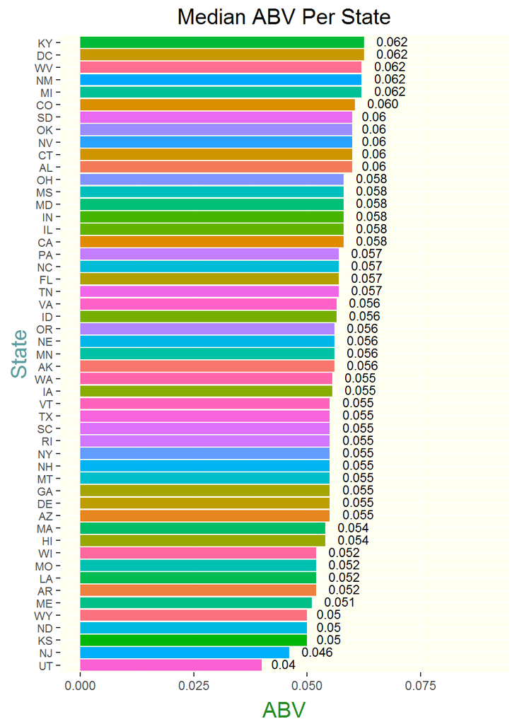

```r
###Steps below are to identify median ABV per style and update our model dataframe values accordingly###
#Separate IBU and Style into separate dataframe
abv_style_df <- beersAndPubs[,c("ABV","Style")]

#Calculate mean IBU per Style.  Also, rename column headers.
mn_abv <- aggregate(abv_style_df$ABV, by=list(abv_style_df$Style), FUN=median)
names(mn_abv) <- c("Style", "ABV")

#Plot Median ABV Per State
ggplot(data=medianABVbyState, aes(x=reorder(State,ABV),y=ABV,fill=State)) +
  geom_bar(stat="identity", show.legend = F) +
  ggtitle("Median ABV Per State") +
  coord_flip() +
  geom_text(
            data = medianABVbyState,
            aes(y = ABV, label = substr(ABV,0,5)), size = 3,
            vjust = .35, hjust=-.4) +
  ylim(0,0.09) +
  xlab("State") +
  theme(
        panel.background = element_rect(fill = 'ivory1'),
        plot.title = element_text(hjust = 0.5, size=15),
        axis.text.y = element_text(size=8),
        axis.title.x = element_text(color="forestgreen", vjust=-0.35, size=15),
        axis.title.y = element_text(color="cadetblue" , vjust=0.35, size=15)
        )
```

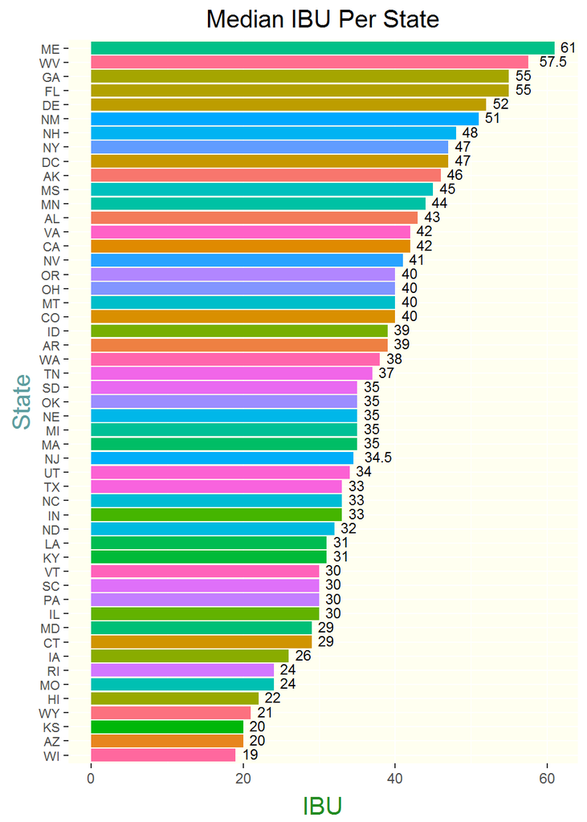

```r
#Plot Median IBU Per State
ggplot(data=medianIBUbyState, aes(x=reorder(State,IBU),y=IBU,fill=State)) +
  geom_bar(stat="identity", show.legend = F) +
  ggtitle("Median IBU Per State") +
  coord_flip() +
  geom_text(
            data = medianIBUbyState,
            aes(y = IBU, label = substr(IBU,0,5)), size = 3,
            vjust = .35, hjust=-.4
            ) +
  xlab("State")+
  theme(
        panel.background = element_rect(fill = 'ivory1'),
        plot.title = element_text(hjust = 0.5, size=15),
        axis.text.y = element_text(size=8),
        axis.title.x = element_text(color="forestgreen", vjust=-0.35, size=15),
        axis.title.y = element_text(color="cadetblue" , vjust=0.35, size=15)
        )
```

#### 6. Summary statistics for the ABV variable.

The images below display the summary stastics associated to the ABV variable.

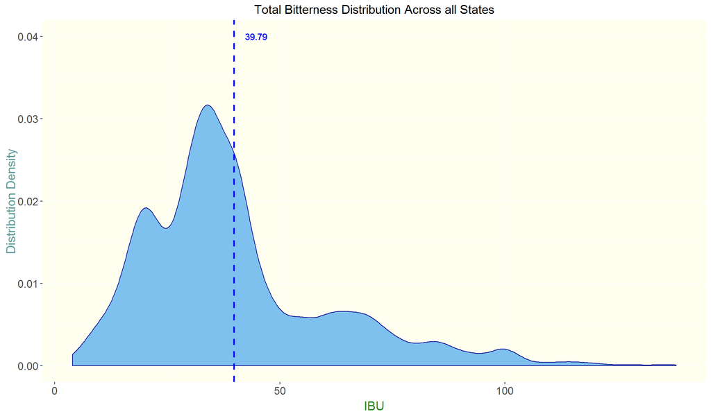

```r
# Probability density distribution for IBU
ggplot(na.omit(beersAndPubs), aes(x=IBU)) +
  geom_density(color="darkblue", fill="skyblue2") +
  geom_vline(aes(xintercept=mean(IBU)),
            color="blue", linetype="dashed", size=1) +
  geom_text(aes(x=mean(IBU), label=round(mean(IBU), digits=2), y=0.04, hjust = -0.5), colour="blue", angle=0) +
  theme(
        panel.background = element_rect(fill = 'ivory1'),
        axis.text.y = element_text(size=13),
        axis.text.x = element_text(size=13),
        axis.title.x = element_text(color="forestgreen", vjust=-0.35, size=15),
        axis.title.y = element_text(color="cadetblue" , vjust=0.35, size=15),
        plot.title = element_text(hjust = 0.5, size=15)
        ) +
  ggtitle("Total Bitterness Distribution Across all States") +
  ylab("Distribution Density")
```

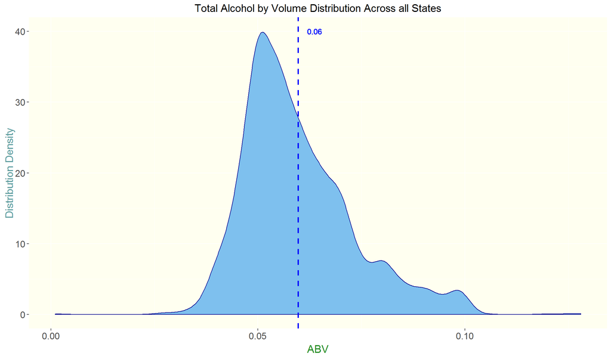

```r
# Probability density distribution for ABV
ggplot(na.omit(beersAndPubs), aes(x=ABV)) +
  geom_density(color="darkblue", fill="skyblue2") +
  geom_vline(aes(xintercept=mean(ABV)),
            color="blue", linetype="dashed", size=1) +
  geom_text(aes(x=mean(ABV), label=round(mean(ABV), digits=2), y=40, hjust = -0.6), colour="blue", angle=0) +
  theme(
        panel.background = element_rect(fill = 'ivory1'),
        plot.title = element_text(hjust = 0.5, size=15),
        axis.text.y = element_text(size=13),
        axis.text.x = element_text(size=13),
        axis.title.x = element_text(color="forestgreen", vjust=-0.35, size=15),
        axis.title.y = element_text(color="cadetblue" , vjust=0.35, size=15)
        ) +
  ggtitle("Total Alcohol by Volume Distribution Across all States") +
  ylab("Distribution Density")
```

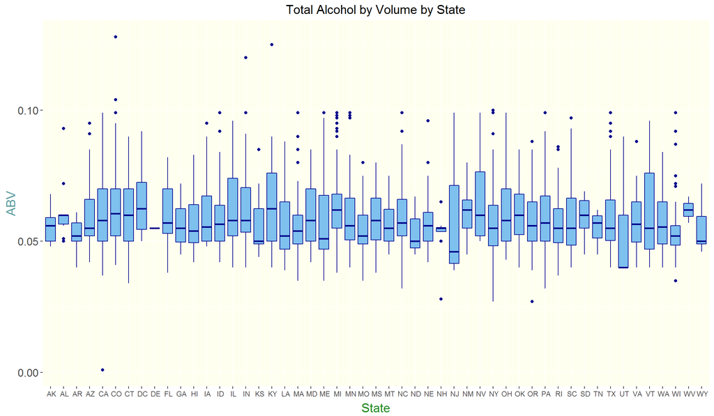

```r
### Boxplots
# ABV by State
ggplot(data=na.omit(beersAndPubs), aes(y=ABV,x=State)) +
  geom_boxplot(stat="boxplot", fill="skyblue2", color="darkblue") +
  theme(
        panel.background = element_rect(fill = 'ivory1'),
        plot.title = element_text(hjust = 0.5, size=15),
        axis.text.y = element_text(size=13),
        axis.title.x = element_text(color="forestgreen", vjust=-0.35, size=15),
        axis.title.y = element_text(color="cadetblue" , vjust=0.35, size=15)
        ) +
  ggtitle("Total Alcohol by Volume by State") +
  xlab("State")
```

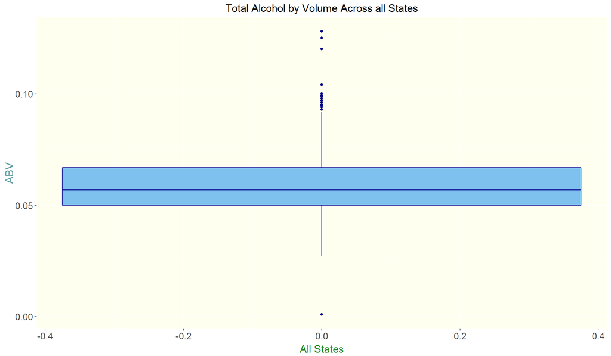

```r
# ABV Nationally
ggplot(data=na.omit(beersAndPubs), aes(y=ABV)) +
  geom_boxplot(stat="boxplot", fill="skyblue2", color="darkblue") +
  theme(
        panel.background = element_rect(fill = 'ivory1'),
        plot.title = element_text(hjust = 0.5, size=15),
        axis.text.y = element_text(size=13),
        axis.text.x = element_text(size=13),
        axis.title.x = element_text(color="forestgreen", vjust=-0.35, size=15),
        axis.title.y = element_text(color="cadetblue" , vjust=0.35, size=15)
        ) +
  ggtitle("Total Alcohol by Volume Across all States") +
  xlab("All States")
```

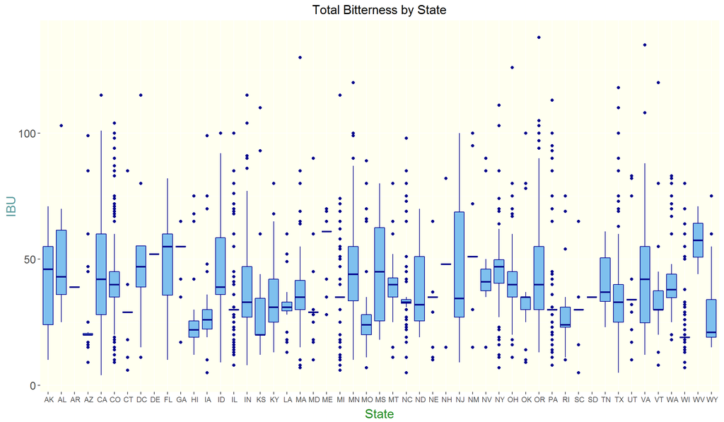

```r
# IBU by State
ggplot(data=na.omit(beersAndPubs), aes(y=IBU,x=State)) +
  geom_boxplot(stat="boxplot", fill="skyblue2", color="darkblue") +
  theme(
        panel.background = element_rect(fill = 'ivory1'),
        plot.title = element_text(hjust = 0.5, size=15),
        axis.text.y = element_text(size=13),
        axis.title.x = element_text(color="forestgreen", vjust=-0.35, size=15),
        axis.title.y = element_text(color="cadetblue" , vjust=0.35, size=15)
        ) +
  ggtitle("Total Bitterness by State") +
  xlab("State")
```

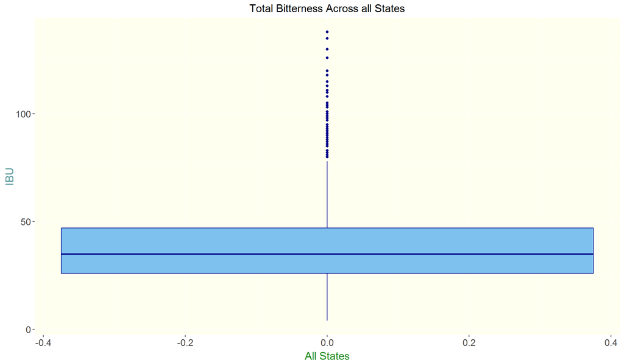

```r
# IBU Nationally
ggplot(data=na.omit(beersAndPubs), aes(y=IBU)) +
  geom_boxplot(stat="boxplot", fill="skyblue2", color="darkblue") +
  theme(
        panel.background = element_rect(fill = 'ivory1'),
        plot.title = element_text(hjust = 0.5, size=15),
        axis.text.y = element_text(size=13),
        axis.text.x = element_text(size=13),
        axis.title.x = element_text(color="forestgreen", vjust=-0.35, size=15),
        axis.title.y = element_text(color="cadetblue" , vjust=0.35, size=15)
        ) +
  ggtitle("Total Bitterness Across all States") +
  xlab("All States")
```

#### 7. Is there an apparent relationship between the bitterness of the beer and its alcoholic content? Draw a scatter plot.

After reviewing a scatterplot comparing the Total Alochol by Volume vs Bitterness, there is a slight correlation between the two factors. As you can see within the image below, the slope within the blue simple linear regression line is positive, thus confirming there is a relationship between the bitterness of the beer and its alcoholic content.

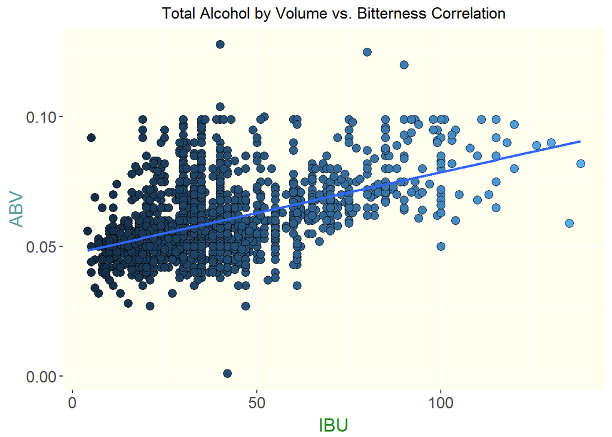

```r
#plot of IBU vs ABV with simple linear regression line
ggplot(beersAndPubs, aes(x=IBU, y=ABV, fill = IBU)) +
    geom_point(size=3, shape=21) +
    geom_smooth(method=lm, se=FALSE) +
  theme(
        panel.background = element_rect(fill = 'ivory1'),
        plot.title = element_text(hjust = 0.5),
        legend.position = "none",
        axis.text.x = element_text(size=13),
        axis.text.y = element_text(size=13),
        axis.title.x = element_text(color="forestgreen", vjust=-0.35, size=15),
        axis.title.y = element_text(color="cadetblue" , vjust=0.35, size=15)
        ) +
  ggtitle("Total Alcohol by Volume vs. Bitterness Correlation")
```